# classification_tree_splitting_method

The packages used are the following :

```r
library(ggplot2)
library(tidyverse)
library(rgl)
```

# Gini criterion and new criterion

We will compare the Gini criterion and the desired new criterion. As an example, we implement a very simple criterion equal to the maximum frequency within the node.

```r
gini <- function(vec, type){
  if(type == 'values'){vec <- table(vec)/sum(table(vec))}
  if(type == 'table'){vec <- vec/sum(vec)}
  res <- 1 - sum(vec^2)
  return(res)
}

newcrit <- function(vec, type){
  if(type == 'values'){vec <- table(vec)/sum(table(vec))}
  if(type == 'table'){vec <- vec/sum(vec)}
  res <- max(vec)
  return(1 - res)
}
```

We assume two classes: A and B. The following graph shows the value of each index as a function of the proportion of observations in class A.

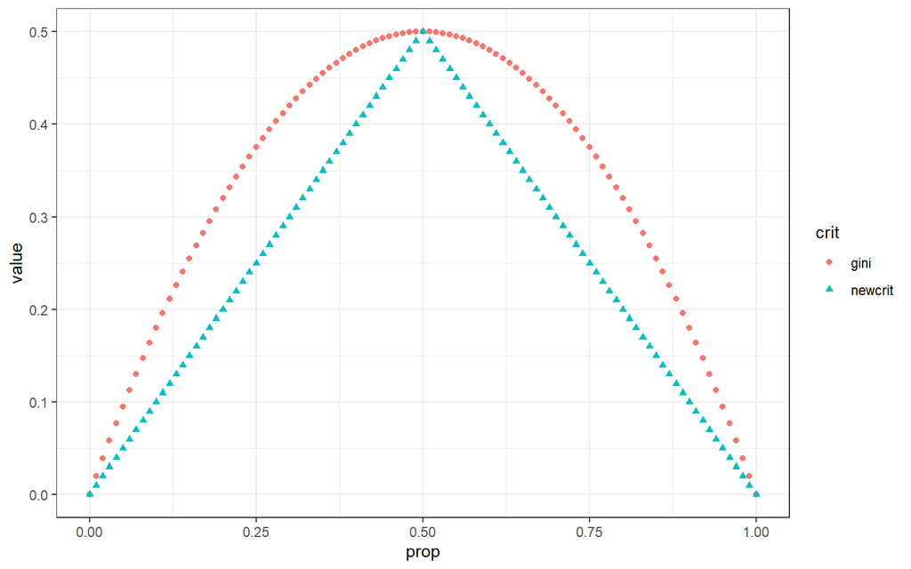

```r
grid1 <- seq(0, 1, 0.01)

grid1_res <- cbind("gini", grid1, sapply(grid1, FUN = function(x) gini(c(x, 1 - x), type = "prop")))

grid1_res <- rbind(grid1_res, cbind("newcrit", grid1, sapply(grid1, FUN = function(x) newcrit(c(x, 1 - x), type = "prop")))) %>% as.data.frame()

colnames(grid1_res) =  c("crit", "prop", "value")
grid1_res$crit <- as.factor(grid1_res$crit)
grid1_res[, 2:3] <- lapply(grid1_res[, 2:3], as.numeric)

ggplot(grid1_res) +
  geom_point(aes(x = prop, y = value, col = crit, shape = crit)) +
  theme_bw()
```

The same work is done assuming we have 3 classes.

```r
grid2 <- NULL
for(i in seq(0, 1, 0.01)){
  for(j in seq(0, 1- i, 0.01)){
    grid2 <- rbind(grid2, c(i, j))
  }
}

grid_gini <- cbind(grid2, apply(grid2[, 1:2], 1, function(x) gini(c(x[1], x[2], 1 - x[1] - x[2]), type = "prop")))
grid_criter <- cbind(grid2, apply(grid2[, 1:2], 1, function(x) newcrit(c(x[1], x[2], 1 - x[1] - x[2]), type = "prop")))

plot3d(x = grid_gini[,1], y = grid_gini[,2], z = grid_gini[,3],
       xlab = "Proportion A", ylab = "Proportion B", zlab = "Gini",
       col = "red")

plot3d(x = grid_criter[,1], y = grid_criter[,2], z = grid_criter[,3],
       xlab = "Proportion A", ylab = "Proportion B", zlab = "newcrit",
       col = "blue")
```

The proportion of a class is set to 1/3 so that the graph can be projected onto two dimensions.

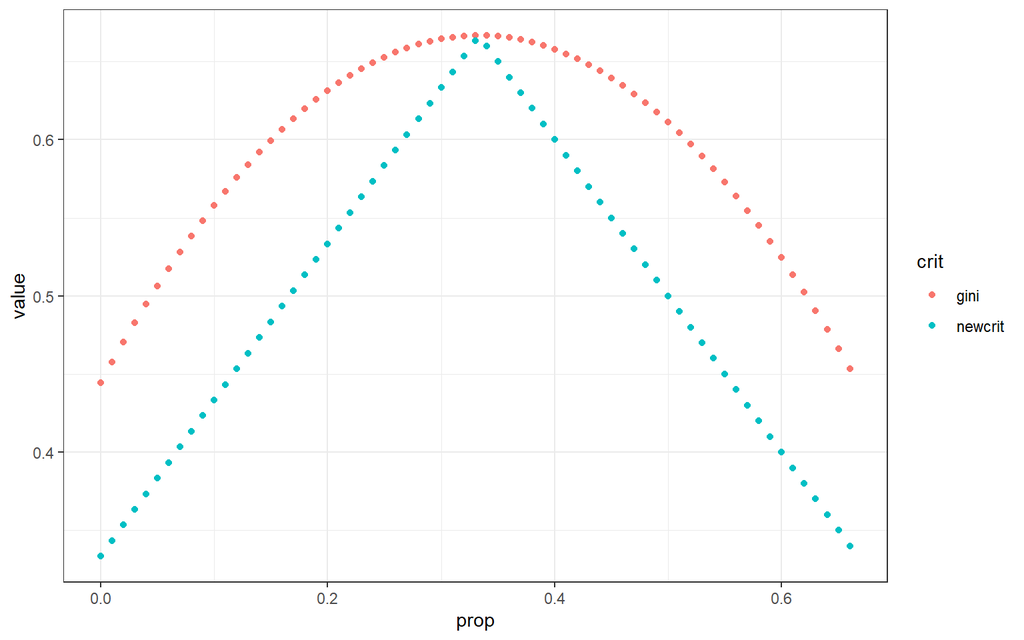

```r
fix <- 1/3

grid3 <- grid1[grid1 <= (1-fix)]

grid1_res <- cbind("gini", grid3, sapply(grid3, FUN = function(x) gini(c(x, (1-fix) - x, fix), type = "prop")))

grid1_res <- rbind(grid1_res, cbind("newcrit", grid3, sapply(grid3, FUN = function(x) newcrit(c(x, (1-fix) - x, fix), type = "prop")))) %>% as.data.frame()

colnames(grid1_res) =  c("crit", "prop", "value")
grid1_res$crit <- as.factor(grid1_res$crit)
grid1_res[, 2:3] <- lapply(grid1_res[, 2:3], as.numeric)

ggplot(grid1_res) +
  geom_point(aes(x = prop, y = value, col = crit)) +
  theme_bw()
```

# Example application on a dataset

Creation of delta functions that should be maximized to find the optimal cut-off:

```r
delta_criter <- function(vec, vecL, vecR, type){
  if(type == 'values'){
    vec <- table(vec)
    vecL <- table(vecL)
    vecR <- table(vecR)
  }
  delta <- newcrit(vec, "table") - sum(vecL)*newcrit(vecL, "table")/sum(vec) - sum(vecR)*newcrit(vecR, "table")/sum(vec)
  return(delta)
}

delta_gini <- function(vec, vecL, vecR, type){
  if(type == 'values'){
    vec <- table(vec)
    vecL <- table(vecL)
    vecR <- table(vecR)
  }
  delta <- gini(vec, "table") - sum(vecL)*gini(vecL, "table")/sum(vec) - sum(vecR)*gini(vecR, "table")/sum(vec)
  return(delta)
}
```

Application with the Gini Index

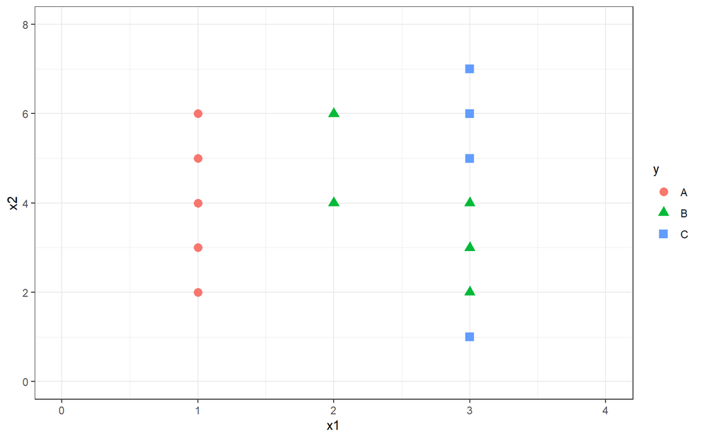

```r
df <- data.frame(y = c(rep("A", 5), rep("B", 5), rep("C", 4)),
           x1 = c(1,1,1,1,1,2,2,3,3,3,3,3,3,3),
           x2 = c(2,3,4,5,6,4,6,2,3,4,1,5,6,7))

ggplot(df) +
  geom_point(aes(x = x1, y = x2, col = y, shape = y), size = 3) +
  xlim(0, 4) +
  ylim(0,8) +
  theme_bw()
```

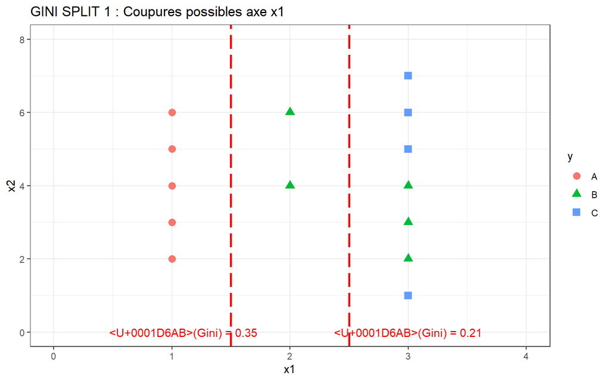

```r
# COUPURE 1

val1 <- delta_gini(c(5, 5 ,4), c(5, 0, 0), c(0, 5, 4), "table") %>% round(2)
val2 <- delta_gini(c(5, 5 ,4), c(5, 2, 0), c(0, 3, 4), "table") %>% round(2)
values <- paste("𝚫(Gini) =", c(val1, val2))

ggplot(df) +
  geom_point(aes(x = x1, y = x2, col = y, shape = y), size = 3) +
  xlim(0, 4) +
  ylim(0,8) +
  theme_bw() +
  geom_vline(xintercept = 1.5, linetype = "longdash", size = 1, col = 'red') +
  geom_vline(xintercept = 2.5, linetype = "longdash", size = 1, col = 'red') +
  geom_text(data = data.frame(values), aes(x = c(1.1, 3), y = 0, label = values), col = 'red') +
  labs(title = "GINI SPLIT 1 : Coupures possibles axe x1")
```

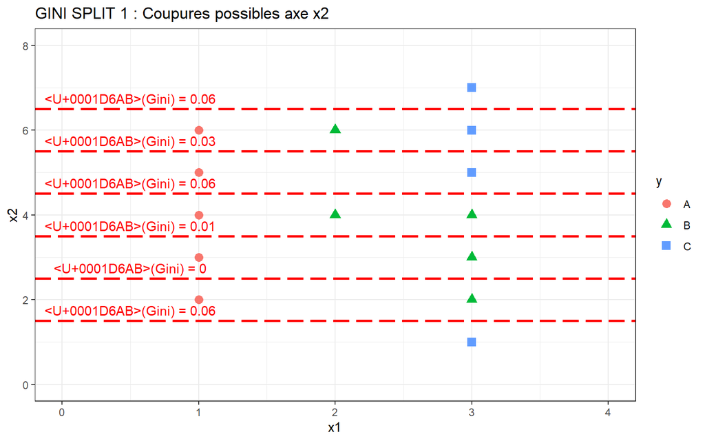

```r
val3 <- delta_gini(c(5, 5 ,4), c(0, 0, 1), c(5, 5, 3), "table") %>% round(2)
val4 <- delta_gini(c(5, 5 ,4), c(1, 1, 1), c(4, 4, 3), "table") %>% round(2)
val5 <- delta_gini(c(5, 5 ,4), c(2, 2, 1), c(3, 3, 3), "table") %>% round(2)
val6 <- delta_gini(c(5, 5 ,4), c(3, 4, 1), c(2, 1, 3), "table") %>% round(2)
val7 <- delta_gini(c(5, 5 ,4), c(4, 4, 2), c(1, 1, 2), "table") %>% round(2)
val8 <- delta_gini(c(5, 5 ,4), c(5, 5, 3), c(0, 0, 1), "table") %>% round(2)
values <- paste("𝚫(Gini) =", c(val3, val4, val5, val6, val7, val8))

ggplot(df) +
  geom_point(aes(x = x1, y = x2, col = y, shape = y), size = 3) +
  xlim(0, 4) +
  ylim(0,8) +
  theme_bw() +
  geom_hline(yintercept = seq(1.5, 6.5, 1), linetype = "longdash", size = 1, col = 'red') +
  geom_text(data = data.frame(values), aes(x = 0.5, y = seq(1.5, 6.5, 1) + 0.25, label = values), col = 'red') +
  labs(title = "GINI SPLIT 1 : Coupures possibles axe x2")
```

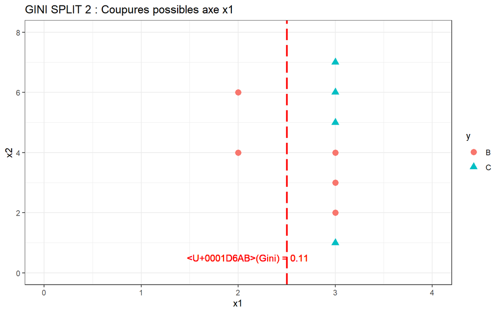

```r
# COUPURE 2

df1 <- df[-c(1:5),]

val1 <- delta_gini(c(0, 5 ,4), c(0, 2, 0), c(0, 3, 4), "table") %>% round(2)
value <-  paste("𝚫(Gini) =", val1)

ggplot(df1) +
  geom_point(aes(x = x1, y = x2, col = y, shape = y), size = 3) +
  xlim(0, 4) +
  ylim(0,8) +
  theme_bw() +
  geom_vline(xintercept = 2.5, linetype = "longdash", size = 1, col = 'red') +
  geom_text(aes(x = 2.1, y = 0.5, label = value), col = 'red') +
  labs(title = "GINI SPLIT 2 : Coupures possibles axe x1")
```

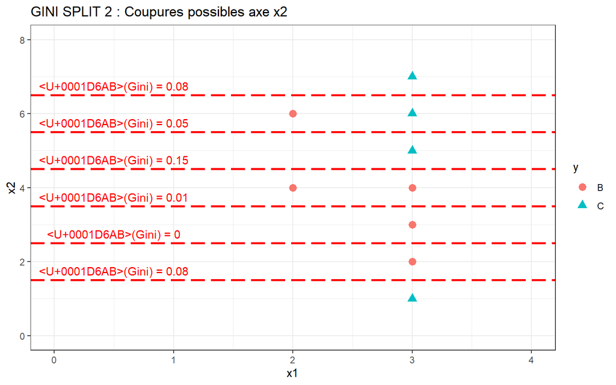

```r
val1 <- delta_gini(c(0, 5 ,4), c(0, 0, 1), c(0, 5, 3), "table") %>% round(2)
val2 <- delta_gini(c(0, 5 ,4), c(0, 1, 1), c(0, 4, 3), "table") %>% round(2)
val3 <- delta_gini(c(0, 5 ,4), c(0, 2, 1), c(0, 3, 3), "table") %>% round(2)
val4 <- delta_gini(c(0, 5 ,4), c(0, 4, 1), c(0, 1, 3), "table") %>% round(2)
val5 <- delta_gini(c(0, 5 ,4), c(0, 4, 2), c(0, 1, 2), "table") %>% round(2)
val6 <- delta_gini(c(0, 5 ,4), c(0, 5, 3), c(0, 0, 1), "table") %>% round(2)
values <-  paste("𝚫(Gini) =", c(val1, val2, val3, val4, val5, val6))

ggplot(df1) +
  geom_point(aes(x = x1, y = x2, col = y, shape = y), size = 3) +
  xlim(0, 4) +
  ylim(0,8) +
  theme_bw() +
  geom_hline(yintercept = seq(1.5, 6.5, 1), linetype = "longdash", size = 1, col = 'red') +
  geom_text(data = data.frame(values), aes(x = 0.5, y = seq(1.5, 6.5, 1) + 0.25, label = values), col = 'red') +
  labs(title = "GINI SPLIT 2 : Coupures possibles axe x2")
```

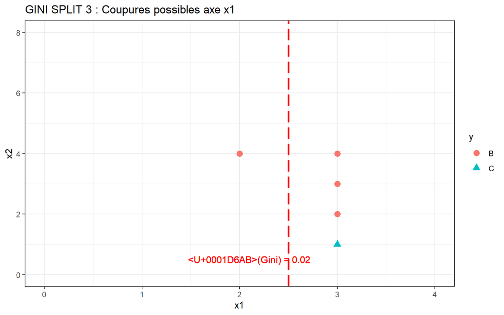

```r
# COUPURE 3

df2 <- df[c(6,8,9,10,11),]

val1 <- delta_gini(c(0, 4 ,1), c(0, 1, 0), c(0, 3, 1), "table") %>% round(2)
value <- paste("𝚫(Gini) =", val1)

ggplot(df2) +
  geom_point(aes(x = x1, y = x2, col = y, shape = y), size = 3) +
  xlim(0, 4) +
  ylim(0,8) +
  theme_bw() +
  geom_vline(xintercept = 2.5, linetype = "longdash", size = 1, col = 'red') +
  geom_text(aes(x = 2.1, y = 0.5, label = value), col = 'red') +
  labs(title = "GINI SPLIT 3 : Coupures possibles axe x1")
```

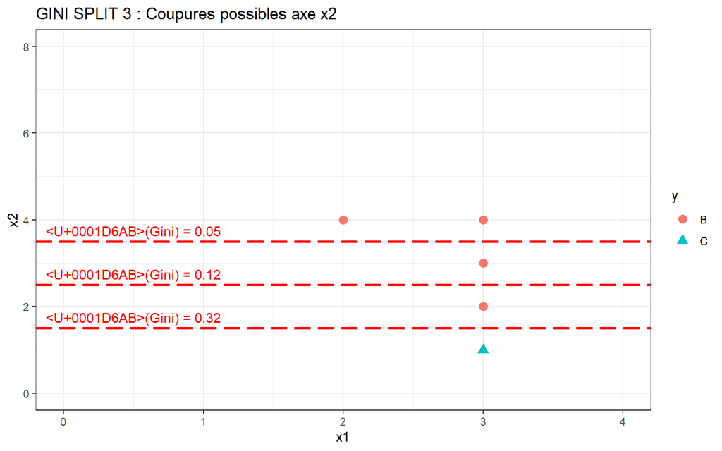

```r
val2 <- delta_gini(c(0, 4 ,1), c(0, 4, 0), c(0, 0, 1), "table") %>% round(2)
val3 <- delta_gini(c(0, 4 ,1), c(0, 1, 1), c(0, 0, 3), "table") %>% round(2)
val4 <- delta_gini(c(0, 4 ,1), c(0, 2, 1), c(0, 0, 2), "table") %>% round(2)
values <- paste("𝚫(Gini) =", c(val2, val3, val4))

ggplot(df2) +
  geom_point(aes(x = x1, y = x2, col = y, shape = y), size = 3) +
  xlim(0, 4) +
  ylim(0,8) +
  theme_bw() +
  geom_hline(yintercept = seq(1.5, 3.5, 1), linetype = "longdash", size = 1, col = 'red') +
  geom_text(data = data.frame(values), aes(x = 0.5, y = seq(1.5, 3.5, 1) + 0.25, label = values), col = 'red') +
  labs(title = "GINI SPLIT 3 : Coupures possibles axe x2")
```

Application with the new criterion

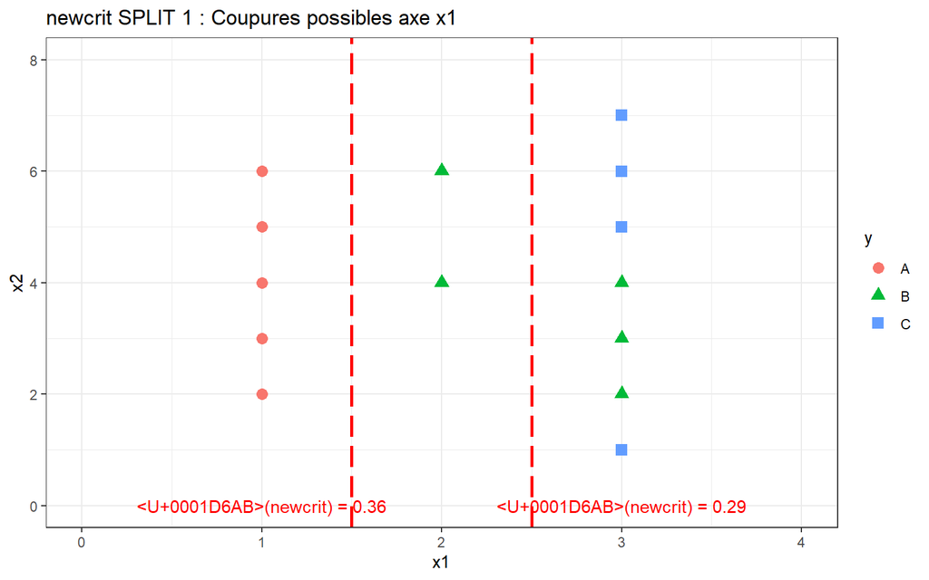

```r
# COUPURE 1

val1 <- delta_criter(c(5, 5 ,4), c(5, 0, 0), c(0, 5, 4), "table") %>% round(2)
val2 <- delta_criter(c(5, 5 ,4), c(5, 2, 0), c(0, 3, 4), "table") %>% round(2)
values <- paste("𝚫(newcrit) =", c(val1, val2))

ggplot(df) +
  geom_point(aes(x = x1, y = x2, col = y, shape = y), size = 3) +
  xlim(0, 4) +
  ylim(0,8) +
  theme_bw() +
  geom_vline(xintercept = 1.5, linetype = "longdash", size = 1, col = 'red') +
  geom_vline(xintercept = 2.5, linetype = "longdash", size = 1, col = 'red') +
  geom_text(data = data.frame(values), aes(x = c(1, 3), y = 0, label = values), col = 'red') +
  labs(title = "newcrit SPLIT 1 : Coupures possibles axe x1")
```

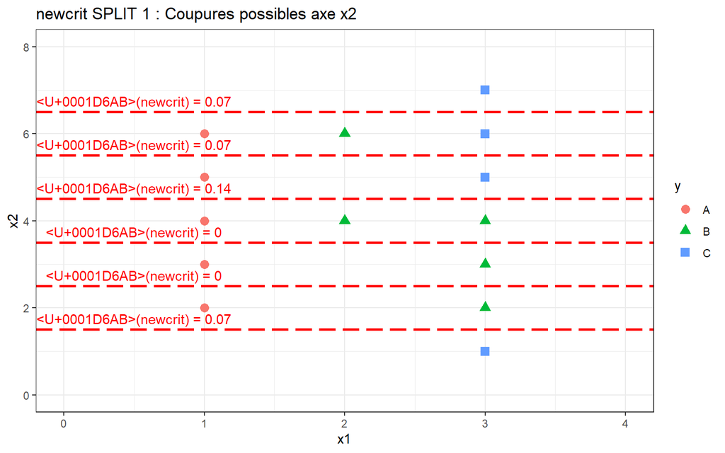

```r
val3 <- delta_criter(c(5, 5 ,4), c(0, 0, 1), c(5, 5, 3), "table") %>% round(2)
val4 <- delta_criter(c(5, 5 ,4), c(1, 1, 1), c(4, 4, 3), "table") %>% round(2)
val5 <- delta_criter(c(5, 5 ,4), c(2, 2, 1), c(3, 3, 3), "table") %>% round(2)
val6 <- delta_criter(c(5, 5 ,4), c(3, 4, 1), c(2, 1, 3), "table") %>% round(2)
val7 <- delta_criter(c(5, 5 ,4), c(4, 4, 2), c(1, 1, 2), "table") %>% round(2)
val8 <- delta_criter(c(5, 5 ,4), c(5, 5, 3), c(0, 0, 1), "table") %>% round(2)
values <- paste("𝚫(newcrit) =", c(val3, val4, val5, val6, val7, val8))

ggplot(df) +
  geom_point(aes(x = x1, y = x2, col = y, shape = y), size = 3) +
  xlim(0, 4) +
  ylim(0,8) +
  theme_bw() +
  geom_hline(yintercept = seq(1.5, 6.5, 1), linetype = "longdash", size = 1, col = 'red') +
  geom_text(data = data.frame(values), aes(x = 0.5, y = seq(1.5, 6.5, 1) + 0.25, label = values), col = 'red') +
  labs(title = "newcrit SPLIT 1 : Coupures possibles axe x2")
```

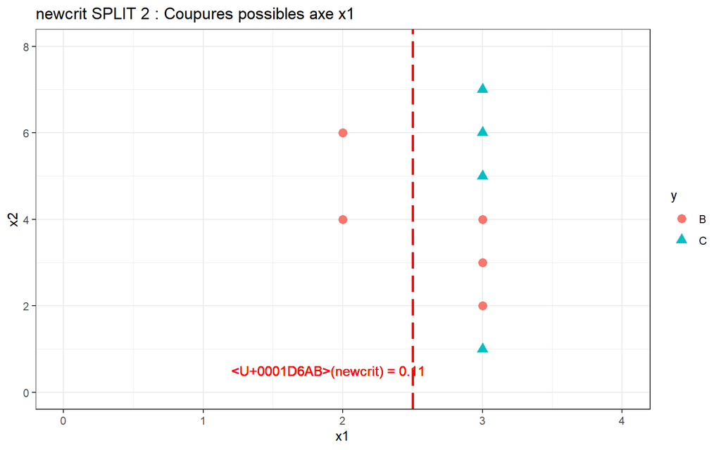

```r
# COUPURE 2

df1 <- df[-c(1:5),]

val1 <- delta_criter(c(0, 5 ,4), c(0, 2, 0), c(0, 3, 4), "table") %>% round(2)
value <-  paste("𝚫(newcrit) =", val1)

ggplot(df1) +
  geom_point(aes(x = x1, y = x2, col = y, shape = y), size = 3) +
  xlim(0, 4) +
  ylim(0,8) +
  theme_bw() +
  geom_vline(xintercept = 2.5, linetype = "longdash", size = 1, col = 'red') +
  geom_text(aes(x = 1.9, y = 0.5, label = value), col = 'red') +
  labs(title = "newcrit SPLIT 2 : Coupures possibles axe x1")
```

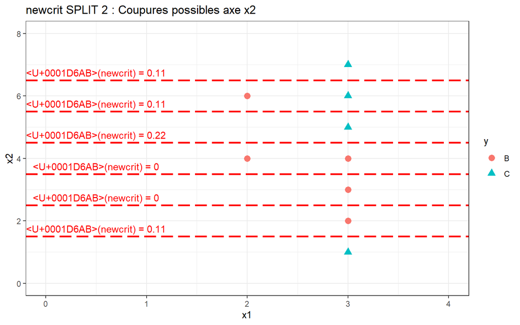

```r
val1 <- delta_criter(c(0, 5 ,4), c(0, 0, 1), c(0, 5, 3), "table") %>% round(2)
val2 <- delta_criter(c(0, 5 ,4), c(0, 1, 1), c(0, 4, 3), "table") %>% round(2)
val3 <- delta_criter(c(0, 5 ,4), c(0, 2, 1), c(0, 3, 3), "table") %>% round(2)
val4 <- delta_criter(c(0, 5 ,4), c(0, 4, 1), c(0, 1, 3), "table") %>% round(2)
val5 <- delta_criter(c(0, 5 ,4), c(0, 4, 2), c(0, 1, 2), "table") %>% round(2)
val6 <- delta_criter(c(0, 5 ,4), c(0, 5, 3), c(0, 0, 1), "table") %>% round(2)
values <-  paste("𝚫(newcrit) =", c(val1, val2, val3, val4, val5, val6))

ggplot(df1) +
  geom_point(aes(x = x1, y = x2, col = y, shape = y), size = 3) +
  xlim(0, 4) +
  ylim(0,8) +
  theme_bw() +
  geom_hline(yintercept = seq(1.5, 6.5, 1), linetype = "longdash", size = 1, col = 'red') +
  geom_text(data = data.frame(values), aes(x = 0.5, y = seq(1.5, 6.5, 1) + 0.25, label = values), col = 'red') +
  labs(title = "newcrit SPLIT 2 : Coupures possibles axe x2")
```

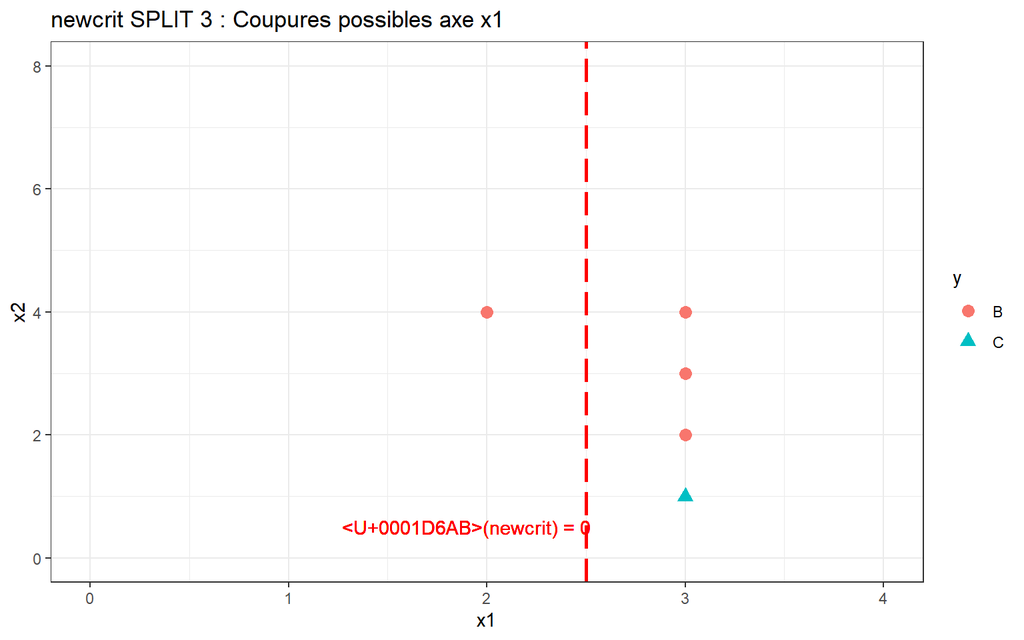

```r
# COUPURE 3

df2 <- df[c(6,8,9,10,11),]

val1 <- delta_criter(c(0, 4 ,1), c(0, 1, 0), c(0, 3, 1), "table") %>% round(2)
value <- paste("𝚫(newcrit) =", val1)

ggplot(df2) +
  geom_point(aes(x = x1, y = x2, col = y, shape = y), size = 3) +
  xlim(0, 4) +
  ylim(0,8) +
  theme_bw() +
  geom_vline(xintercept = 2.5, linetype = "longdash", size = 1, col = 'red') +
  geom_text(aes(x = 1.9, y = 0.5, label = value), col = 'red') +
  labs(title = "newcrit SPLIT 3 : Coupures possibles axe x1")
```

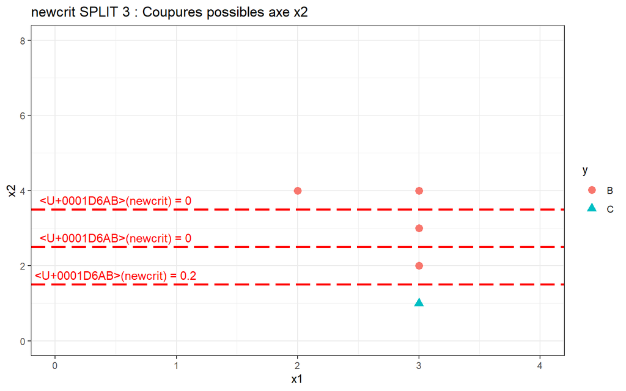

```r
val2 <- delta_criter(c(0, 4 ,1), c(0, 4, 0), c(0, 0, 1), "table") %>% round(2)
val3 <- delta_criter(c(0, 4 ,1), c(0, 1, 1), c(0, 0, 3), "table") %>% round(2)
val4 <- delta_criter(c(0, 4 ,1), c(0, 2, 1), c(0, 0, 2), "table") %>% round(2)
values <- paste("𝚫(newcrit) =", c(val2, val3, val4))

ggplot(df2) +
  geom_point(aes(x = x1, y = x2, col = y, shape = y), size = 3) +
  xlim(0, 4) +
  ylim(0,8) +
  theme_bw() +
  geom_hline(yintercept = seq(1.5, 3.5, 1), linetype = "longdash", size = 1, col = 'red') +
  geom_text(data = data.frame(values), aes(x = 0.5, y = seq(1.5, 3.5, 1) + 0.25, label = values), col = 'red') +
  labs(title = "newcrit SPLIT 3 : Coupures possibles axe x2")
```

# Application on existing datasets

All the following functions are intended to implement the decision tree function.

```r
indice <- function(to_cut, seuil, y, indic){
  whereL <- which(to_cut <= seuil)
  whereR <- which(to_cut > seuil)
  if(indic == "gini"){
    delta_gini(y[c(whereL,whereR)], y[whereL], y[whereR], type = "values")
  } else if (indic == 'newcrit'){
    delta_criter(y[c(whereL,whereR)], y[whereL], y[whereR], type = "values")
  }
}

all_cut <- function(df, y, to_cut, indic){
  vals <- sort(unique(df[,to_cut]))
  vals <- vals[-length(vals)]

  data.frame(to_cut = to_cut ,
             cut = vals,
             indice = sapply(vals, FUN = function(x) indice(df[,to_cut], x, df[, y] ,indic)))
}

clean_df <- function(df, tokeep){

  tab_unique <- apply(df[, colnames(df) != tokeep], FUN = function(x) length(unique(x)), MARGIN = 2)
  col_not_unique <- names(tab_unique[tab_unique != 1])
  df1 <- df1[, c(col_not_unique, tokeep)]

}

find_opt <- function(df, yname, indic){

  v <- apply(df[, colnames(df) != yname], FUN = function(x) length(unique(x)), MARGIN = 2)
  col_ <- names(v[v != 1])

  result <- lapply(col_, FUN = function(x) all_cut(df[,], yname, x, indic)) %>% bind_rows()
  idx <- which.max(result$indice)

  return(list(to_cut = result$to_cut[idx],
                            cut = result$cut[idx]))

}

accuracy_table <- function(res, n){
  accuracy <- data.frame(matrix(ncol = 2, nrow = 0))
  colnames(accuracy) <- c("depth", "accuracy")
  for(i in unique(res$depth)){

    locs <- which(res$depth == i)

    n_err <- 0
    for(loc in locs){

      tab <- res$table[loc][[1]]

      n_err <- n_err + (sum(tab) - max(tab))

    }

    accuracy <- accuracy %>% add_row(depth = i,
                                     accuracy = 1 - n_err/n)
  }
    return(accuracy)
}

rpart_scratch <- function(df, yname, n_depth, indic){

  df[, yname] <- as.factor(df[, yname])

  res <- data.frame(depth = 0,
                    node = 1,
                    type = "to do",
                    where = I(list(1:nrow(df))),
                    table = I(list(table(df[, yname]))),
                    pred_ = which.max(table(df[, yname])) %>% names(),
                    to_cut = NA,
                    cut = NA)

  for(i in 1:n_depth){

    if(sum(res$type == "to do") == 0){
      break
    }

    locs <- which(res$type == "to do")

    for(loc in locs){

    d <- res$depth[loc]
    id_node <- res$node[loc]

    where <- res$where[loc][[1]]

    if(sum(table(df[where, yname]) != 0) == 1){

      res[loc, 'type'] <- "leaf"

    } else {

      result <- find_opt(df[where,], yname, indic)

      res[loc, 'to_cut'] <- result$to_cut
      res[loc, 'cut'] <- result$cut
      res[loc, 'type'] <- "node"

      whereL <- where[where %in% which(df[, result$to_cut] <= result$cut)]
      whereR <- where[where %in% which(df[, result$to_cut] > result$cut)]

      res <- res %>% add_row(depth = c(d + 1, d + 1),
                      node = c(id_node * 2, id_node *2 + 1),
                      type = c("to do", "to do"),
                      where = c(I(list(whereL)), I(list(whereR))),
                      table = c(I(list(table(df[whereL, yname]))), I(list(table(df[whereR, yname])))),
                      pred_ = c(names(which.max(table(df[whereL, yname]))), names(which.max(table(df[whereR, yname])))))

    }
    }
  }
  return(res)
}

rpart_scratch_pred <- function(obs, res){
  node <- 1
  pred_ <- NULL
  for(i in 1:50){
  if(!is.null(pred_)){
    break
  }
  loc <- which(res$node == node)
  if(sum(res$node == 2 * node) == 0){
    pred_ <- res$pred_[loc]
  } else {
    if(obs[, res$to_cut[loc]] <= res$cut[loc]){
      node <- node * 2
    } else {
      node <- node * 2 + 1
    }
  }
  }
  return(pred_)
}

rpart_scratch_pred_all <- function(df, res){
  v <- NULL
  for(i in 1:nrow(df)){
    v <- c(v, rpart_scratch_pred(df[i,], res))
  }
  return(v)

}
```

Example of CART application on the IRIS dataset.

Application with the Gini index: the following table describes the leaves of the tree obtained as well as the nodes and their optimal splitting.

```r
rpart_scratch(iris, "Species", 6, 'gini')
```

```
##    depth node type        where      table      pred_       to_cut cut
## 1      0    1 node 1, 2, 3,.... 50, 50, 50     setosa Petal.Length 1.9
## 2      1    2 leaf 1, 2, 3,....   50, 0, 0     setosa         <NA>  NA
## 3      1    3 node 51, 52, ....  0, 50, 50 versicolor  Petal.Width 1.7
## 4      2    6 node 51, 52, ....   0, 49, 5 versicolor Petal.Length 4.9
## 5      2    7 node 71, 101,....   0, 1, 45  virginica Petal.Length 4.8
## 6      3   12 node 51, 52, ....   0, 47, 1 versicolor  Petal.Width 1.6
## 7      3   13 node 78, 84, ....    0, 2, 4  virginica  Petal.Width 1.5
## 8      3   14 node 71, 127, 139    0, 1, 2  virginica Sepal.Length 5.9
## 9      3   15 leaf 101, 102....   0, 0, 43  virginica         <NA>  NA
## 10     4   24 leaf 51, 52, ....   0, 47, 0 versicolor         <NA>  NA
## 11     4   25 leaf          107    0, 0, 1  virginica         <NA>  NA
## 12     4   26 leaf 120, 134....    0, 0, 3  virginica         <NA>  NA
## 13     4   27 node  78, 84, 130    0, 2, 1 versicolor Sepal.Length 6.7
## 14     4   28 leaf           71    0, 1, 0 versicolor         <NA>  NA
## 15     4   29 leaf     127, 139    0, 0, 2  virginica         <NA>  NA
## 16     5   54 leaf       78, 84    0, 2, 0 versicolor         <NA>  NA
## 17     5   55 leaf          130    0, 0, 1  virginica         <NA>  NA
```

```r
rpart_scratch(iris, "Species", 6, 'newcrit')
```

```
##    depth node  type        where      table      pred_       to_cut cut
## 1      0    1  node 1, 2, 3,.... 50, 50, 50     setosa Petal.Length 1.9
## 2      1    2  leaf 1, 2, 3,....   50, 0, 0     setosa         <NA>  NA
## 3      1    3  node 51, 52, ....  0, 50, 50 versicolor  Petal.Width 1.6
## 4      2    6  node 51, 52, ....   0, 48, 4 versicolor Petal.Length 4.9
## 5      2    7  node 71, 78, ....   0, 2, 46  virginica Sepal.Length 4.9
## 6      3   12  leaf 51, 52, ....   0, 47, 0 versicolor         <NA>  NA
## 7      3   13  node 84, 120,....    0, 1, 4  virginica Sepal.Length 6.0
## 8      3   14  leaf          107    0, 0, 1  virginica         <NA>  NA
## 9      3   15  node 71, 78, ....   0, 2, 45  virginica  Petal.Width 1.7
## 10     4   26  node      84, 120    0, 1, 1 versicolor  Sepal.Width 2.2
## 11     4   27  leaf 130, 134....    0, 0, 3  virginica         <NA>  NA
## 12     4   30  leaf           78    0, 1, 0 versicolor         <NA>  NA
## 13     4   31  node 71, 101,....   0, 1, 45  virginica Petal.Length 6.0
## 14     5   52  leaf          120    0, 0, 1  virginica         <NA>  NA
## 15     5   53  leaf           84    0, 1, 0 versicolor         <NA>  NA
## 16     5   62  node 71, 101,....   0, 1, 36  virginica  Sepal.Width 2.9
## 17     5   63  leaf 106, 108....    0, 0, 9  virginica         <NA>  NA
## 18     6  124 to do 102, 104....   0, 0, 13  virginica         <NA>  NA
## 19     6  125 to do 71, 101,....   0, 1, 23  virginica         <NA>  NA
```

The following code allows you to do the cross-validation to compare the two criteria. All you have to do is set the dataframe in the df object and the name of the variable of interest in the yname object.

Cross validation on IRIS :

```r
df <- iris
yname <- 'Species'


taille <- nrow(df)%/%10
reste <- nrow(df) - 10 * taille
bloc <- sample(c(rep(1:10, taille), sample(10, reste)))

v <- NULL
for(d in 1:7){
  cat(d, "\n")
  for(b in 1:10){
    cat("/t", b, "\n")

    res_gini <- rpart_scratch(df[bloc != b,], yname, d, 'gini')
    pred_gini <- rpart_scratch_pred_all(df[bloc == b, colnames(df) != yname], res_gini)
    res_newcrit <- rpart_scratch(df[bloc != b,], yname, d, 'newcrit')
    pred_newcrit <- rpart_scratch_pred_all(df[bloc == b, colnames(df) != yname], res_newcrit)
    acc_gini <- sum(pred_gini == df[bloc == b, yname]) / length(pred_gini)
    acc_newcrit <- sum(pred_newcrit == df[bloc == b, yname]) / length(pred_newcrit)

    v <- rbind(v,
               c(d, b, acc_gini, acc_newcrit))
  }
}
```

[output not shown]

[output cut: 22 more lines]

[output not shown]

```r
colnames(v) <- c("depth", "bloc", "acc_gini", "acc_newcrit")
v <- as.data.frame(v)

v %>%
  group_by(depth) %>%
  summarise(acc_gini = mean(acc_gini),
            acc_newcrit = mean(acc_newcrit))
```

```
## # A tibble: 7 x 3
##   depth acc_gini acc_newcrit
##   <dbl>    <dbl>       <dbl>
## 1     1    0.6         0.6
## 2     2    0.927       0.927
## 3     3    0.947       0.953
## 4     4    0.94        0.94
## 5     5    0.94        0.94
## 6     6    0.94        0.933
## 7     7    0.94        0.933
```

Application on ZOO

```r
# Code pour le jeu de données zoo
df <- read.csv("zoo.csv", header = T)
yname <- 'class_type'
df <- df[, -1]


taille <- nrow(df)%/%10
reste <- nrow(df) - 10 * taille
bloc <- sample(c(rep(1:10, taille), sample(10, reste)))

v <- NULL
for(d in 1:7){
  cat(d, "\n")
  for(b in 1:10){
    cat("/t", b, "\n")

    res_gini <- rpart_scratch(df[bloc != b,], yname, d, 'gini')
    pred_gini <- rpart_scratch_pred_all(df[bloc == b, colnames(df) != yname], res_gini)
    res_newcrit <- rpart_scratch(df[bloc != b,], yname, d, 'newcrit')
    pred_newcrit <- rpart_scratch_pred_all(df[bloc == b, colnames(df) != yname], res_newcrit)
    acc_gini <- sum(pred_gini == df[bloc == b, yname]) / length(pred_gini)
    acc_newcrit <- sum(pred_newcrit == df[bloc == b, yname]) / length(pred_newcrit)

    v <- rbind(v,
               c(d, b, acc_gini, acc_newcrit))
  }
}
```

[output not shown]

[output cut: 22 more lines]

[output not shown]

```r
colnames(v) <- c("depth", "bloc", "acc_gini", "acc_newcrit")
v <- as.data.frame(v)

v %>%
  group_by(depth) %>%
  summarise(acc_gini = mean(acc_gini),
            acc_newcrit = mean(acc_newcrit))
```

```
## # A tibble: 7 x 3
##   depth acc_gini acc_newcrit
##   <dbl>    <dbl>       <dbl>
## 1     1    0.605       0.605
## 2     2    0.735       0.735
## 3     3    0.804       0.804
## 4     4    0.824       0.851
## 5     5    0.911       0.921
## 6     6    0.931       0.931
## 7     7    0.96        0.921
```